# Final_Report

2025-12-12

# Analysis on How a Movie’s Budget Affects Its Box Office and Critical Success

## Introduction

The goal of this project is to explore a dataset and determine how different factors affect a movie’s success.

There are two main questions I plan on exploring:

1. What are the relations between a movie’s budget and its box office and critical success?
2. What kind of relationship is there between a movie’s genre and its box office performance, are certain genres more successful than others?

## Data

This dataset comes from kaggle, specfically https://www.kaggle.com/datasets/abdallahwagih/movies/data. The dataset is provided as a single zipped csv file with 24 variables, many of which aren’t useful to this analysis.

Loaded the tidyverse library and used it to process the zip file.

```r
library(tidyverse)
movies <- read_csv("movies.csv.zip")
```

### Cleaning

The first step to cleaning the data is choosing the variables that will actually be useful to the analysis.

```r
library(data.table)

movies_clean <- movies %>%
  select(
    title,
    budget,
    revenue,
    vote_average,
    vote_count,
    release_date,
    genres
  )

summary(movies_clean)
```

```
##     title               budget             revenue           vote_average
##  Length:4803        Min.   :        0   Min.   :0.000e+00   Min.   : 0.000
##  Class :character   1st Qu.:   790000   1st Qu.:0.000e+00   1st Qu.: 5.600
##  Mode  :character   Median : 15000000   Median :1.917e+07   Median : 6.200
##                     Mean   : 29045040   Mean   :8.226e+07   Mean   : 6.092
##                     3rd Qu.: 40000000   3rd Qu.:9.292e+07   3rd Qu.: 6.800
##                     Max.   :380000000   Max.   :2.788e+09   Max.   :10.000
##
##    vote_count       release_date           genres
##  Min.   :    0.0   Min.   :1916-09-04   Length:4803
##  1st Qu.:   54.0   1st Qu.:1999-07-14   Class :character
##  Median :  235.0   Median :2005-10-03   Mode  :character
##  Mean   :  690.2   Mean   :2002-12-27
##  3rd Qu.:  737.0   3rd Qu.:2011-02-16
##  Max.   :13752.0   Max.   :2017-02-03
##                    NA's   :1
```

I also decided to extract the year information from the release_date variable, though I don’t use this value for any analysis, I did make a graph to get a better understanding of the data.

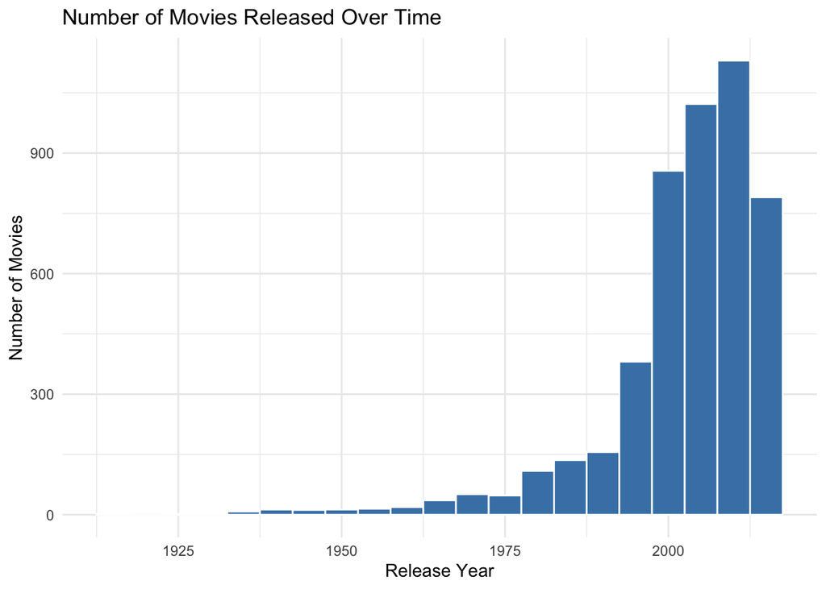

```r
library(lubridate)
library(ggplot2)

movies_clean <- movies_clean %>%
  mutate(
    release_year  = year(release_date)
  )

movies_clean <- movies_clean %>%
  select(-release_date)

ggplot(movies_clean, aes(x = release_year)) +
  geom_histogram(binwidth = 5, fill = "steelblue", color = "white") +
  labs(
    title = "Number of Movies Released Over Time",
    x = "Release Year",
    y = "Number of Movies"
  ) +
  theme_minimal()
```

We can clearly see that the majority of the movies in this dataset have been released in the last 30 or so years. This provides useful context for the rest of the analysis.

Looking at the variables, I felt like revenue wasn’t the best measure of whether a movie was successful so I decided to add a variable “profit,” which is simply equal to a movies revenue minus its budget. This will be useful for seeing how well a movie actually does rather than just how much it made in total.

```r
movies_clean <- movies_clean %>%
  mutate(
    profit = revenue - budget
  )
```

The final thing I did to clean the data is I removed the movies that had a listed budget of less than $100. I did this after making a graph of budget and revenue that had quite a few movies that supposedly had a budget of $0-$100 but made significantly more. This seems more likely to be a mistake in the dataset than reality, so I removed them.

```r
movies_clean <- movies_clean %>%
  filter(
    budget > 100,
    revenue > 0,
    !is.na(release_year)
  )

summary(movies_clean)
```

```
##     title               budget             revenue           vote_average
##  Length:3218        Min.   :      218   Min.   :7.000e+00   Min.   :0.00
##  Class :character   1st Qu.: 11000000   1st Qu.:1.723e+07   1st Qu.:5.80
##  Mode  :character   Median : 25000000   Median :5.556e+07   Median :6.30
##                     Mean   : 40793413   Mean   :1.217e+08   Mean   :6.31
##                     3rd Qu.: 55000000   3rd Qu.:1.470e+08   3rd Qu.:6.90
##                     Max.   :380000000   Max.   :2.788e+09   Max.   :8.50
##    vote_count         genres           release_year      profit
##  Min.   :    0.0   Length:3218        Min.   :1916   Min.   :-165710090
##  1st Qu.:  179.2   Class :character   1st Qu.:1998   1st Qu.:    294131
##  Median :  475.5   Mode  :character   Median :2005   Median :  26762314
##  Mean   :  980.1                      Mean   :2002   Mean   :  80858237
##  3rd Qu.: 1148.8                      3rd Qu.:2010   3rd Qu.:  97731306
##  Max.   :13752.0                      Max.   :2016   Max.   :2550965087
```

## Results

### How does a movie’s budget affect its box office and critical success?

```r
library(scales)
```

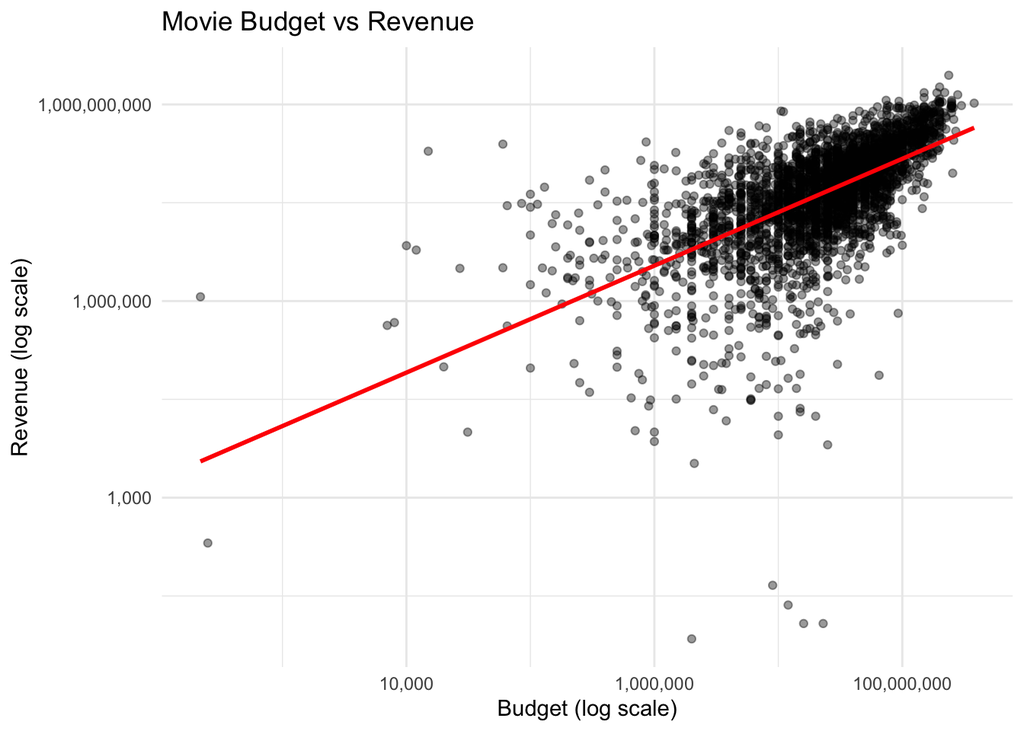

```r
ggplot(movies_clean, aes(x = budget, y = revenue)) +
  geom_point(alpha = 0.4) +
  scale_x_log10(labels = comma) +
  scale_y_log10(labels = comma) +
  geom_smooth(method = "lm", se = FALSE, color = "red") +
  labs(
    title = "Movie Budget vs Revenue",
    x = "Budget (log scale)",
    y = "Revenue (log scale)"
  ) +
  theme_minimal()
```

This graph shows the relationship between a movie’s budget and revenue, it’s more of just making sure of what I expected to be true, it shows that as a movie’s budget increases, the revenue that movie makes is expected to be higher. This is unsurprising but will help us answer the question.

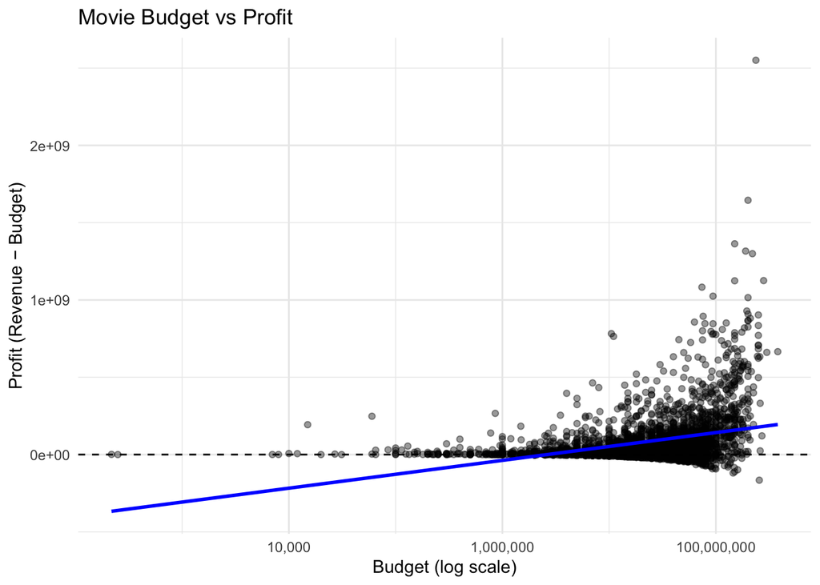

```r
ggplot(movies_clean, aes(x = budget, y = profit)) +
  geom_point(alpha = 0.4) +
  scale_x_log10(labels = comma) +
  geom_hline(yintercept = 0, linetype = "dashed") +
  geom_smooth(method = "lm", se = FALSE, color = "blue") +
  labs(
    title = "Movie Budget vs Profit",
    x = "Budget (log scale)",
    y = "Profit (Revenue − Budget)"
  ) +
  theme_minimal()
```

```r
cor_budget_revenue <- cor(movies_clean$budget, movies_clean$revenue, method = "spearman")
cor_budget_revenue
```

```
## [1] 0.6755467
```

```r
cor_budget_profit  <- cor(movies_clean$budget, movies_clean$profit, method = "spearman")
cor_budget_profit
```

```
## [1] 0.3415413
```

This graph shows the relationship between a movie’s budget and the actual profit it made. This graph shows a slightly positive correlation but it seemed like much weaker of a correlation that that between budget and revenue. To confirm, I used R to check the correlation of both relationships and it confirmed my findings. For budget and revenue, it gave a correlation coefficient of 0.676, which aligns with a moderate positive correlation. While for budget and profit, it gave a correlation coefficient of just 0.342, which aligns with a much weaker correlation.

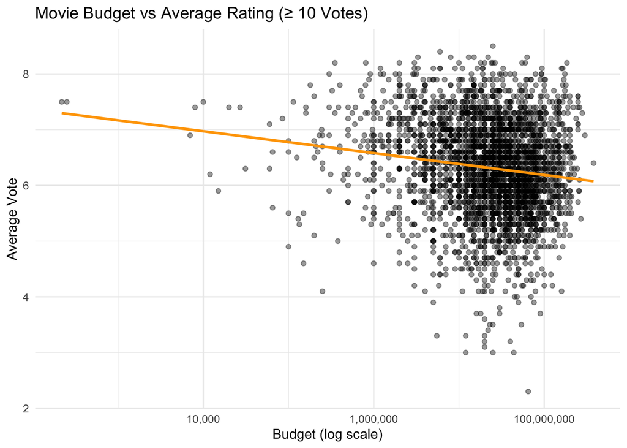

```r
ggplot(
  movies_clean %>% filter(vote_count >= 10),
  aes(x = budget, y = vote_average)
) +
  geom_point(alpha = 0.4) +
  scale_x_log10(labels = comma) +
  geom_smooth(method = "lm", se = FALSE, color = "orange") +
  labs(
    title = "Movie Budget vs Average Rating (≥ 10 Votes)",
    x = "Budget (log scale)",
    y = "Average Vote"
  ) +
  theme_minimal()
```

```r
cor(movies_clean$budget, movies_clean$vote_average, method = "spearman")
```

```
## [1] -0.1389697
```

Using our findings, we can say that while increasing a movie’s budget is generally correlated to an increased box office performance, the same cannot be said for its critical success, where it seems like there’s nearly no correlation between the two.

Due to the way this analysis was does, correlation is the only claim I can make for both research questions, causal relationships are much more difficult to establish so making those claims from this data would be unfounded.

### What kind of relationship is there between a movie’s genre and its box office performance, are certain genres more successful than others?

```r
movies_genres <- movies_clean %>%
  separate_rows(genres, sep = " ")

movies_summary <- movies_genres %>%
  group_by(genres) %>%
  summarize(
    n_movies = n(),
    median_profit = median(profit, na.rm = TRUE),
    mean_profit = mean(profit, na.rm = TRUE)
  ) %>%
  filter(n_movies >= 20)
```

When trying to find how to answer this question, I ran into some problems with the dataset. The ‘genre’ variable for most rows contained multiple different genres, an example of one entry could be “Drama Comedy Thriller.” This made it challenging to work with so I created a new dataframe from movies_clean that would give a movie with multiple genres multiple entries, one for each genre it had. With this dataframe, I added a variable median_profit to help answer the question and didn’t consider any genres with less than 20 movies to focus on the genres that have sufficient data.

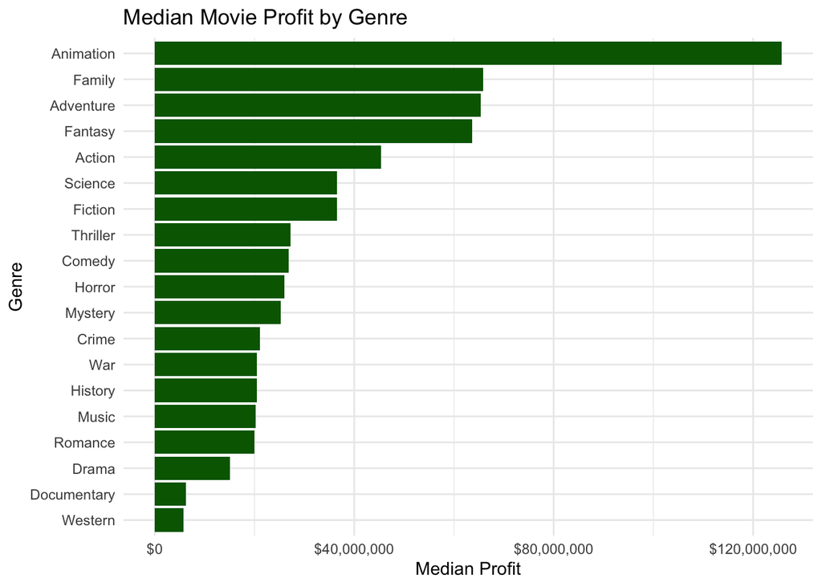

```r
ggplot(movies_summary,
       aes(x = reorder(genres, median_profit), y = median_profit)) +
  geom_col(fill = "darkgreen") +
  coord_flip() +
  scale_y_continuous(labels = dollar) +
  labs(
    title = "Median Movie Profit by Genre",
    x = "Genre",
    y = "Median Profit"
  ) +
  theme_minimal()
```

This graph shows the median profit for every main genre of movie in the dataset.

Using the graph, we can answer the question and say yes, certain genres do certainly seem to be more profitable than others, with Animation, Family, Adventure, and Fantasy movies seeming to be the most lucrative.

## Conclusion

In conclusion, it seems like while there are definitely some factors you can look at to give you an idea, it’s always going to be difficult to tell whether a movie will be successful based on simple factors like budget and genre. This goes even more so for critical success, where it seems like there’s essentially no correlation between critical success and other basic factors.

There’s much more research that could be done on this topic, there are many other variables that could be explored and now 8 more years of movie releases that could be looked into. One thing I’m curious about is whether the trends that were found still hold today given how much Covid changed the movie industry.